# EDA and cleaning on COMPAS data

Applied Data Science Project 4

Chang Lu, Jiaxin Yu, Marcus Loke, Xiran Lin, Zaigham Khan

Spring 2022

```r
# Load required libraries
library(dplyr)
library(ggplot2)
library(grid)
library(gridExtra)
```

# 1 Load the data

We will load the COMPAS data located in `../data/`. Not all features are useful for the analysis, therefore we only select `sex`, `age_cat`, `race`, `priors_count`, `c_charge_degree`, `c_jail_in`, `c_jail_out` and `two_year_recid`.

```r
# Load data and explore
raw_data = read.csv("../data/compas-scores-two-years.csv")
nrow(raw_data)
```

```
## [1] 7214
```

# 2 Clean

There are six different types of races in the data. But since we are only interested in a binary attribute for `race` as dictated by the project guidelines, we will filter the dataset for only `Caucasian` and `African-American`. Note that `race` will be our sensitive attribute.

```r
unique(raw_data$race)
```

```
## [1] "Other"            "African-American" "Caucasian"        "Hispanic"
## [5] "Native American"  "Asian"
```

```r
# Filter data for only Caucasians and African-Americans
# Create new column for length of stay and remove NAs
# Change variables into factors
# Perform normalization
df = raw_data %>%
  select(sex, age_cat, race, priors_count, c_charge_degree, c_jail_in, c_jail_out, two_year_recid) %>%
  filter(race == "Caucasian" | race == "African-American") %>%
  mutate(length_of_stay = as.numeric(as.Date(c_jail_out) - as.Date(c_jail_in))) %>%
  filter(!is.na(length_of_stay)) %>%
  select(sex:c_charge_degree, length_of_stay, two_year_recid) %>%
  mutate(age_cat = recode(age_cat, "Less than 25" = "< 25", "Greater than 45" = "> 45")) %>%
  mutate(sex = factor(sex),
         age_cat = factor(age_cat, levels = c("< 25", "25 - 45", "> 45")),
         race = factor(race, levels = c("Caucasian", "African-American")),
         c_charge_degree = factor(c_charge_degree),
         two_year_recid = factor(two_year_recid)) %>%
  mutate(priors_count = (priors_count - mean(priors_count)) / sd(priors_count),
         length_of_stay = (length_of_stay - mean(length_of_stay)) / sd(length_of_stay))
nrow(df)
```

```
## [1] 5915
```

# 3 Explore

```r
table(df$race)
```

```
##
##        Caucasian African-American
##             2378             3537
```

Below we plot the proportion of black and white defendants by their gender and whether they recidivated within two years. Some salient observations:

- The proportion of black male defendants is greater than that of white male defendants. The same can be said of female defendants but the proportion is quite similar for black female and white female defendants.
- Proportionally, there is a higher amount of younger black defendants than white defendants (in the “< 25” and the “25 - 45” category). The proportion of black defendants decreases with age while the proportion of white defendants increases with age.
- There is a (slight) higher number of black defendants with previous felonies than white defendants.
- Black defendants have higher recidivation (within 2 years) as compared to white defendants.

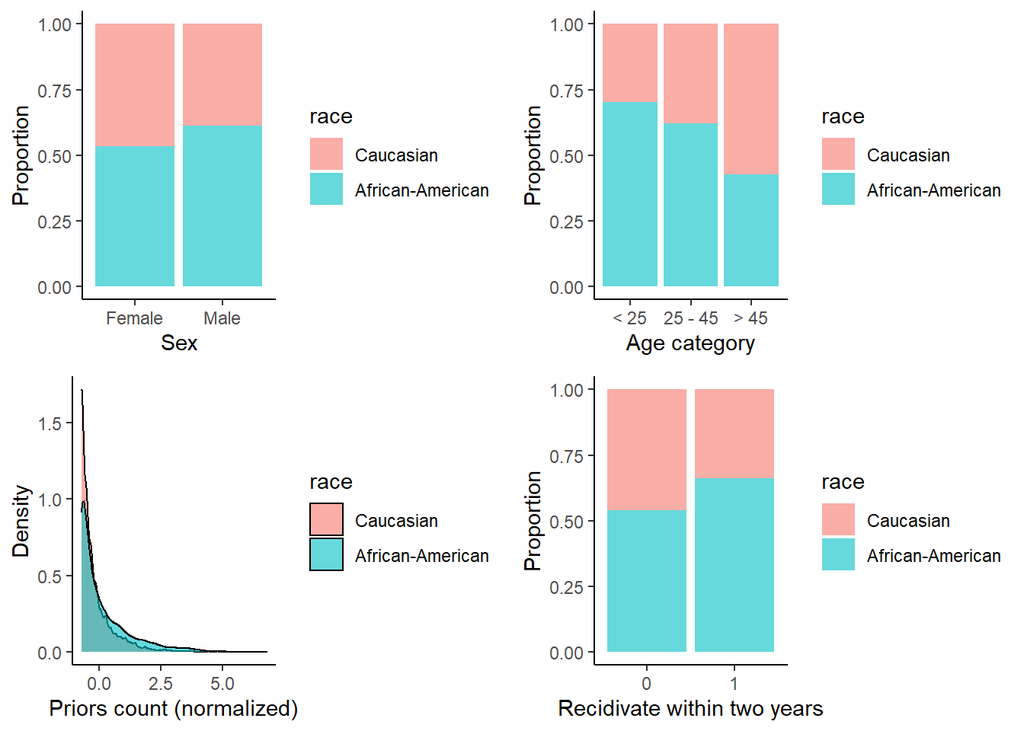

```r
p_sex_race = df %>%
  ggplot(aes(x=sex, fill=race)) +
  geom_bar(position = "fill", alpha = 0.6) +
  theme_classic() +
  labs(x = "Sex",
       y = "Proportion")

p_age_race = df %>%
  ggplot(aes(x=age_cat, fill=race)) +
  geom_bar(position = "fill", alpha = 0.6) +
  theme_classic() +
  labs(x = "Age category",
       y = "Proportion")

p_priors_race = df %>%
  ggplot(aes(x=priors_count, fill=race)) +
  geom_density(alpha=0.6) +
  labs(x="Priors count (normalized)", y="Density") +
  theme_classic()

p_recid_race = df %>%
  ggplot(aes(x=two_year_recid, fill=race)) +
  geom_bar(position = "fill", alpha = 0.6) +
  theme_classic() +
  labs(x = "Recidivate within two years",
       y = "Proportion")

grid.arrange(p_sex_race, p_age_race, p_priors_race, p_recid_race, ncol = 2)
```

We also ran a simple logistic regression to understand how each variable interacts with `two_year_recid`.

```r
model = glm(two_year_recid~., data = df, family = "binomial")
summary(model)
```

```
##
## Call:
## glm(formula = two_year_recid ~ ., family = "binomial", data = df)
##
## Deviance Residuals:
##     Min       1Q   Median       3Q      Max
## -3.0379  -1.0104  -0.6439   1.0865   1.9708
##
## Coefficients:
##                      Estimate Std. Error z value Pr(>|z|)
## (Intercept)           0.38552    0.09604   4.014 5.96e-05 ***
## sexMale               0.31628    0.07143   4.428 9.52e-06 ***
## age_cat25 - 45       -0.72934    0.07091 -10.285  < 2e-16 ***
## age_cat> 45          -1.44579    0.09282 -15.576  < 2e-16 ***
## raceAfrican-American  0.09351    0.05905   1.583   0.1133
## priors_count          0.74182    0.03829  19.375  < 2e-16 ***
## c_charge_degreeM     -0.12941    0.06026  -2.148   0.0317 *
## length_of_stay        0.14413    0.03232   4.459 8.22e-06 ***
## ---
## Signif. codes:  0 '***' 0.001 '**' 0.01 '*' 0.05 '.' 0.1 ' ' 1
##
## (Dispersion parameter for binomial family taken to be 1)
##
##     Null deviance: 8188.2  on 5914  degrees of freedom
## Residual deviance: 7338.3  on 5907  degrees of freedom
## AIC: 7354.3
##
## Number of Fisher Scoring iterations: 4
```

Some salient observations:

- Male defendants are 1.37 times more likely to recidivate within 2 years than female defendants.
- The older the defendants are, the less likely they are to recidivate within 2 years as compared to the younger defendants.
- For a unit SD increase in prior felony that a defendant has, they are 2.1 times more likely to recidivate within 2 years.
- Surprisingly, race is not that statistically significant when predicting a defendant’s recidivism rate. It probably means that the other features are more “useful” in predicting recidivism than race.

# 4 Output csv

```r
write.csv(df, "../output/compas-scores-two-years(cleaned).csv", row.names = FALSE)
```